# Diabetes and related factors

ansari.shekoofeh@stud.hs-fresenius.de

07.06.2023

# Source of dataset

The Diabetes dataset originates from the National Institute of Diabetes and Digestive and Kidney Diseases (NIDDK) in the United States. It was specifically created for research purposes, aiming to facilitate the development and evaluation of predictive models for diagnosing diabetes.

The dataset consists of records from 768 individuals, representing a diverse group of female patients aged 21 years and above, primarily of Pima Indian heritage. Each record includes a set of feature values and an associated diabetes outcome

# Features

The Diabetes dataset comprises a range of numerical and categorical features relevant to predicting diabetes. These features include:

- **Pregnancies**: Number of times pregnant
- **Glucose**: Plasma glucose concentration (mg/dL)
- **BloodPressure**: Diastolic blood pressure (mm Hg)
- **SkinThickness**: Triceps skinfold thickness (mm)
- **Insulin**: 2-Hour serum insulin (mu U/ml)
- **BMI**: Body mass index (weight in kg/(height in m)^2)
- **DiabetesPedigreeFunction**: Diabetes pedigree function (a measure of genetic influence)
- **Age**: Age in years

**Outcome**: Diabetes outcome (0 for non-diabetic, 1 for diabetic)

# Display

```
## 'data.frame':    768 obs. of  9 variables:
##  $ Pregnancies             : int  6 1 8 1 0 5 3 10 2 8 ...
##  $ Glucose                 : int  148 85 183 89 137 116 78 115 197 125 ...
##  $ BloodPressure           : int  72 66 64 66 40 74 50 0 70 96 ...
##  $ SkinThickness           : int  35 29 0 23 35 0 32 0 45 0 ...
##  $ Insulin                 : int  0 0 0 94 168 0 88 0 543 0 ...
##  $ BMI                     : num  33.6 26.6 23.3 28.1 43.1 25.6 31 35.3 30.5 0 ...
##  $ DiabetesPedigreeFunction: num  0.627 0.351 0.672 0.167 2.288 ...
##  $ Age                     : int  50 31 32 21 33 30 26 29 53 54 ...
##  $ Outcome                 : int  1 0 1 0 1 0 1 0 1 1 ...
```

# Summary statistics

```
##   Pregnancies        Glucose      BloodPressure    SkinThickness
##  Min.   : 0.000   Min.   :  0.0   Min.   :  0.00   Min.   : 0.00
##  1st Qu.: 1.000   1st Qu.: 99.0   1st Qu.: 62.00   1st Qu.: 0.00
##  Median : 3.000   Median :117.0   Median : 72.00   Median :23.00
##  Mean   : 3.845   Mean   :120.9   Mean   : 69.11   Mean   :20.54
##  3rd Qu.: 6.000   3rd Qu.:140.2   3rd Qu.: 80.00   3rd Qu.:32.00
##  Max.   :17.000   Max.   :199.0   Max.   :122.00   Max.   :99.00
##     Insulin           BMI        DiabetesPedigreeFunction      Age
##  Min.   :  0.0   Min.   : 0.00   Min.   :0.0780           Min.   :21.00
##  1st Qu.:  0.0   1st Qu.:27.30   1st Qu.:0.2437           1st Qu.:24.00
##  Median : 30.5   Median :32.00   Median :0.3725           Median :29.00
##  Mean   : 79.8   Mean   :31.99   Mean   :0.4719           Mean   :33.24
##  3rd Qu.:127.2   3rd Qu.:36.60   3rd Qu.:0.6262           3rd Qu.:41.00
##  Max.   :846.0   Max.   :67.10   Max.   :2.4200           Max.   :81.00
##     Outcome
##  Min.   :0.000
##  1st Qu.:0.000
##  Median :0.000
##  Mean   :0.349
##  3rd Qu.:1.000
##  Max.   :1.000
```

# Diabetes

There are three main types of diabetes mellitus:

**Type 1 diabetes:** failure of the pancreas to $\underline{produce \ enough \ insulin}$ due to loss of beta cells

**Type 2 diabetes:** begins with insulin resistance, a condition in which cells $\underline{fail \ to \ respond \ to \ insulin}$ properly.

**Gestational diabetes:** occurs when pregnant women - without a previous history of diabetes develop high blood sugar levels

# Pregnancy

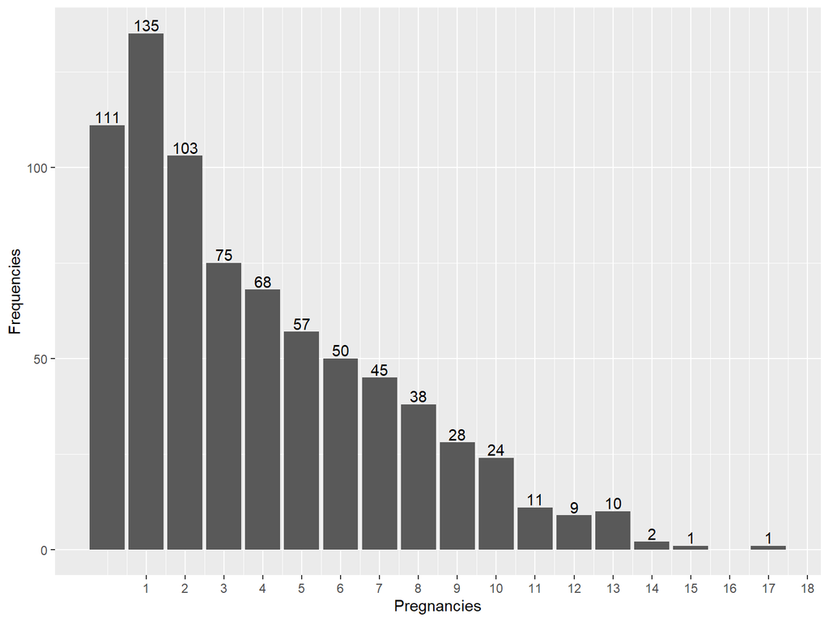

# BMI

$$BMI=\frac{Weight_{(kg)}}{Height^2_{(m)}}$$

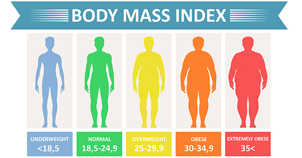

# Ages

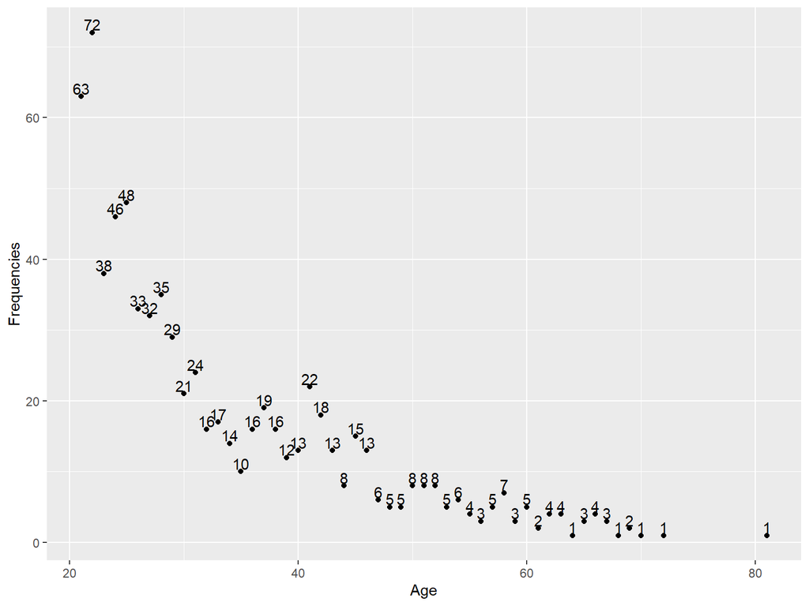

# Regression

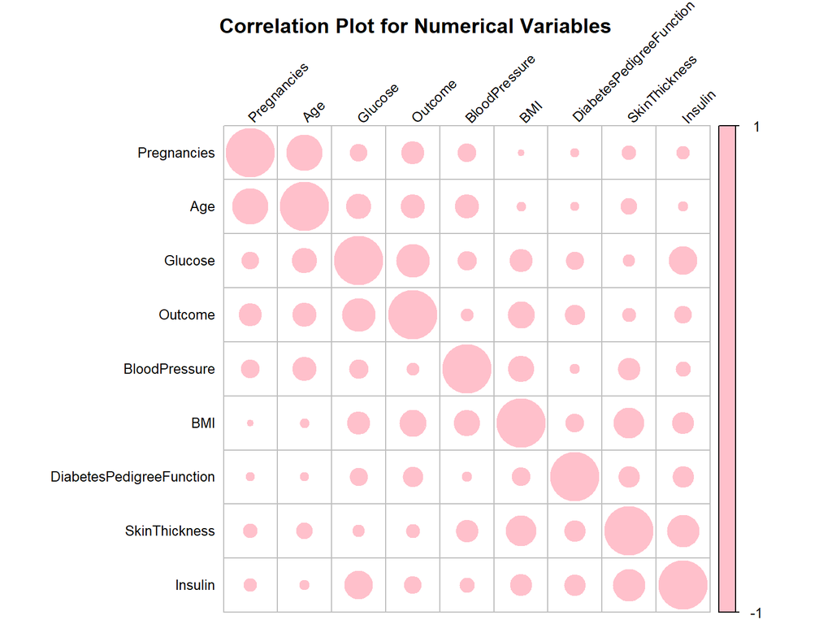

# Road map

1.We will collect the data.

2.Then , we’ll import data set to read our data from a CSV file and manipulate it for further use.

3.We’ll also use Knit to convert out data into a format suitable to feed our classification model.

4.We will use many packages for visualizations.

5.Then,we import logistic regression algorithm and cross validation.

6.Lastly, we have some conclusion about relation between diabetes and some factors.

# Some references

1.https://towardsdatascience.com/end-to-end-data-science-example-predicting-diabetes-with-logistic-regression-db9bc88b4d16

2.https://www.cdc.gov/diabetes/basics/diabetes.html#:~:text=Diabetes%20is%20a%20chronic%20(long,your%20pancreas%20 to%20release%20insulin.

3.National Diabetes Data Group (US), National Institute of Diabetes and Kidney Diseases (US), 1995. Diabetes in America (No. 95). National Institutes of Health, National Institute of Diabetes and Digestive and Kidney Diseases.

4.Forouhi, N.G. and Wareham, N.J., 2010. Epidemiology of diabetes. Medicine, 38(11), pp.602-606.

5.https://r-graph-gallery.com/scatterplot.html

6.Disease Control, Centers for, and Prevention. 2022. “What Is Diabetes?” https://www.cdc.gov/diabetes/basics/diabetes.html#print.

**THANKS FOR YOUR ATTENTION**